# finalrep

Osman Batuhan Şahin

13 01 2022

## Including Libraries

```r
library(dplyr)
```

```r
library(stringr)
library(corrplot)
library(ggplot2)
library(caret)
library(ROSE)
library(factoextra)
library(NbClust)

options(warn=-1)
```

## Data Description

I found my dataset from UCI. You can visit page with this url: https://archive.ics.uci.edu/ml/datasets/diabetes+130-us+hospitals+for+years+1999-2008 This dataset is about diabetes patients of 130 hospitals in the USA between 1999-2008. Contains 101,766 rows and 50 columns.

```r
data = read.csv("diabetic_data.csv", stringsAsFactors = TRUE)

head(data)
```

```
##   encounter_id patient_nbr            race gender     age weight
## 1      2278392     8222157       Caucasian Female  [0-10)      ?
## 2       149190    55629189       Caucasian Female [10-20)      ?
## 3        64410    86047875 AfricanAmerican Female [20-30)      ?
## 4       500364    82442376       Caucasian   Male [30-40)      ?
## 5        16680    42519267       Caucasian   Male [40-50)      ?
## 6        35754    82637451       Caucasian   Male [50-60)      ?
##   admission_type_id discharge_disposition_id admission_source_id
## 1                 6                       25                   1
## 2                 1                        1                   7
## 3                 1                        1                   7
## 4                 1                        1                   7
## 5                 1                        1                   7
## 6                 2                        1                   2
##   time_in_hospital payer_code        medical_specialty num_lab_procedures
```

[output cut: 55 more lines]

## Missing values

“?” and “Unknown/Invalid” are written for the missing data in the data set. This plots shows them. I replace them with NA.

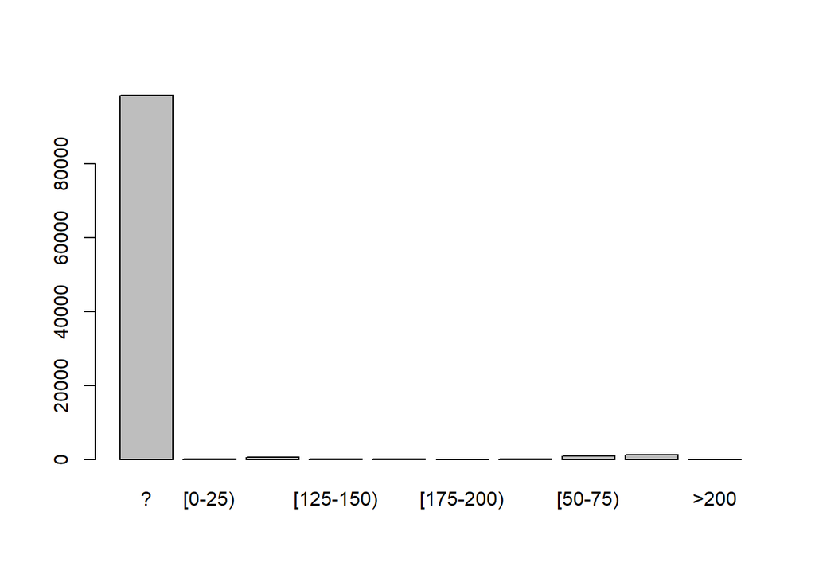

```r
barplot(table(data$weight))
```

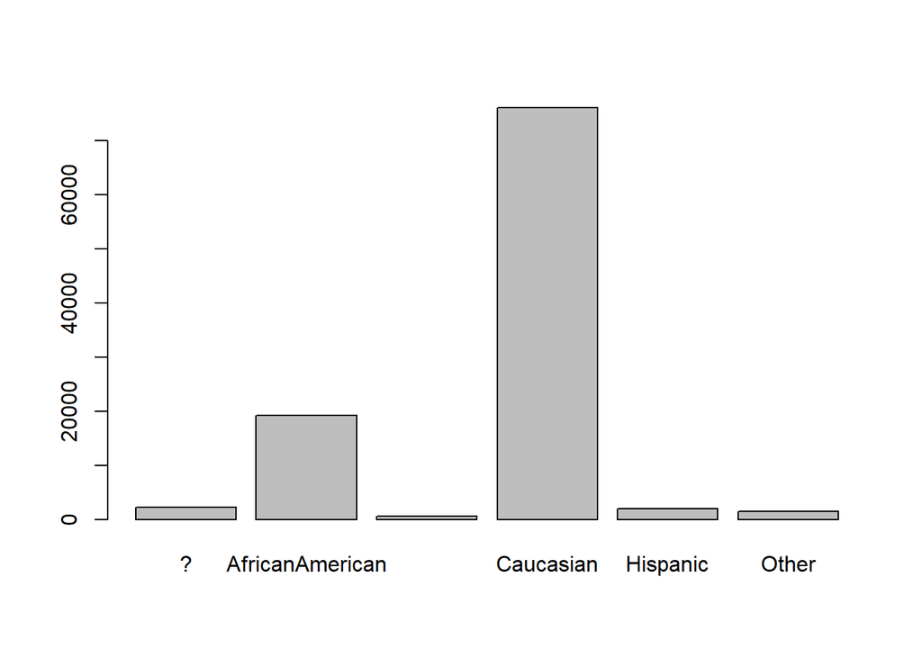

```r
barplot(table(data$race))
```

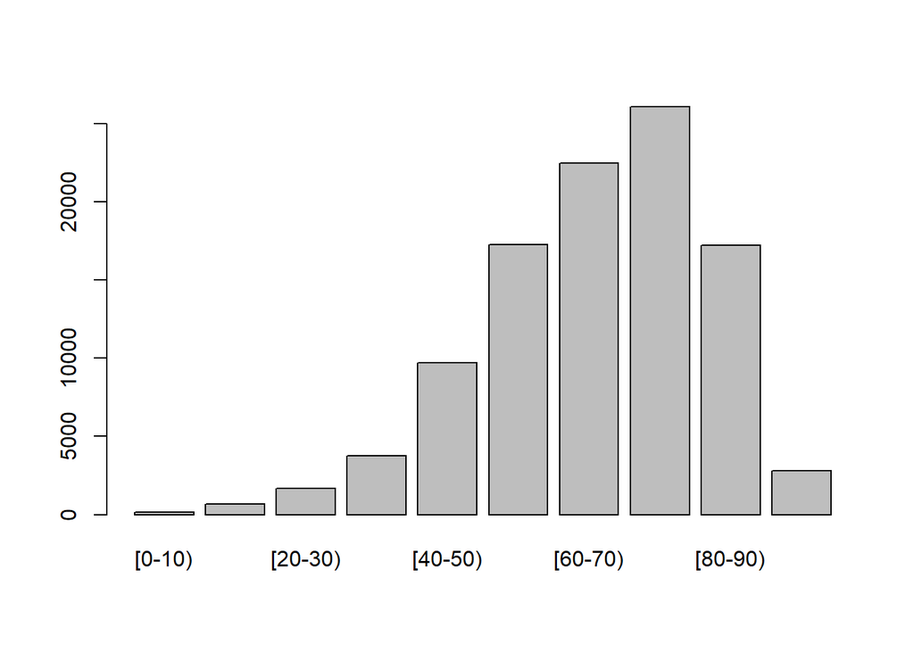

```r
barplot(table(data$age))
```

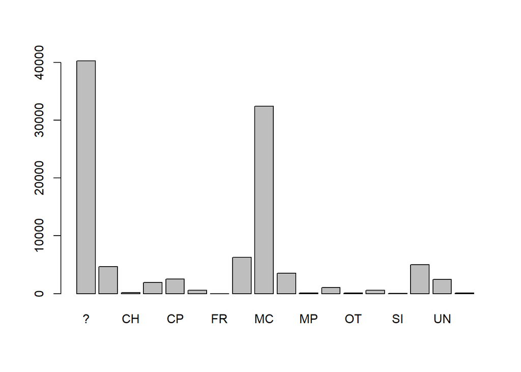

```r
barplot(table(data$payer_code))
```

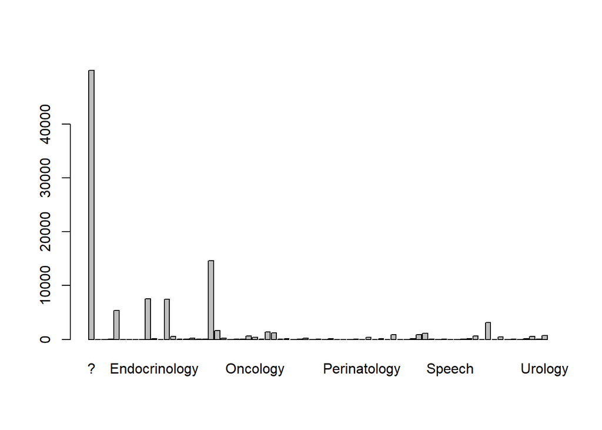

```r
barplot(table(data$medical_specialty))
```

```r
data = na_if(data, "?")
data = na_if(data, "Unknown/Invalid")
```

Number of missing values for each column.

```r
sapply(data, function(x) sum(is.na(x)))
```

```
##             encounter_id              patient_nbr                     race
##                        0                        0                     2273
##                   gender                      age                   weight
##                        3                        0                    98569
##        admission_type_id discharge_disposition_id      admission_source_id
##                        0                        0                        0
##         time_in_hospital               payer_code        medical_specialty
##                        0                    40256                    49949
##       num_lab_procedures           num_procedures          num_medications
##                        0                        0                        0
##        number_outpatient         number_emergency         number_inpatient
##                        0                        0                        0
##                   diag_1                   diag_2                   diag_3
##                       21                      358                     1423
##         number_diagnoses            max_glu_serum                A1Cresult
##                        0                        0                        0
##                metformin              repaglinide              nateglinide
##                        0                        0                        0
##           chlorpropamide              glimepiride            acetohexamide
##                        0                        0                        0
##                glipizide                glyburide              tolbutamide
##                        0                        0                        0
##             pioglitazone            rosiglitazone                 acarbose
##                        0                        0                        0
##                 miglitol             troglitazone               tolazamide
##                        0                        0                        0
##                  examide              citoglipton                  insulin
##                        0                        0                        0
##      glyburide.metformin      glipizide.metformin glimepiride.pioglitazone
##                        0                        0                        0
##  metformin.rosiglitazone   metformin.pioglitazone                   change
##                        0                        0                        0
##              diabetesMed               readmitted
##                        0                        0
```

weight, payer_code and and medical_specialty columns has a lot of missing values. So deleted.

```r
data = select(data, -c(weight, payer_code, medical_specialty))
dim(data)
```

```
## [1] 101766     47
```

Diagnosis 2, Diagnosis 3 deleted. I only use the primary diagnosis.

```r
data = select(data, -c(diag_2, diag_3))
dim(data)
```

```
## [1] 101766     45
```

Citoglipton and examide deleted because all rows have the same value.

```r
table(data$citoglipton)
```

```
##
##     No
## 101766
```

```r
table(data$examide)
```

```
##
##     No
## 101766
```

```r
data = select(data, -c(citoglipton, examide))
dim(data)
```

```
## [1] 101766     43
```

There are 2 csv in data folder: https://archive.ics.uci.edu/ml/machine-learning-databases/00296/ . Second csv show descriptions of admission_type_id, discharge_disposition_id, admission_source_id. I used this csv file in the next steps.

The admission_type_id feature was taking a value between 1-8. The meanings of these values represent “emergency”, “elective”, “new born” and “not available” values in hospitals. Due to this situation, i re-filled the values in our data according to 4 categories: “emergency”, “elective”, “new born” and “other”.

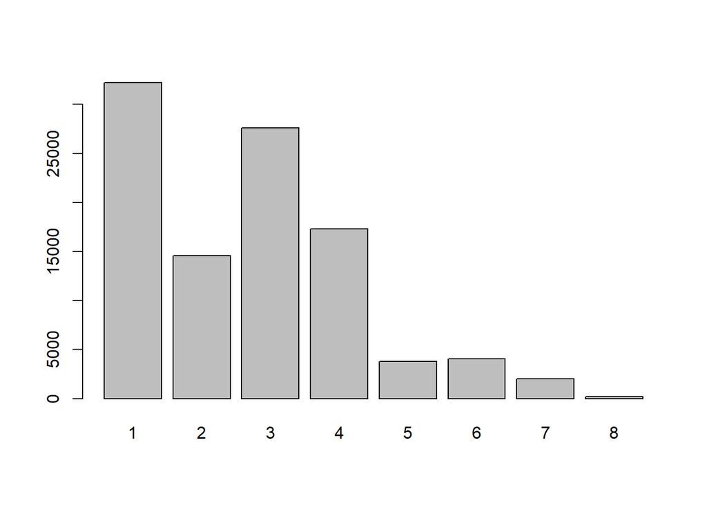

```r
barplot(table(data$admission_type_id))
```

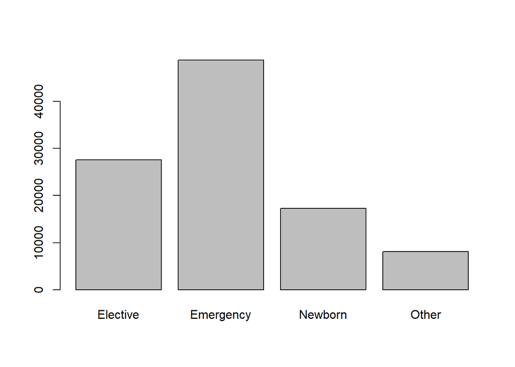

```r
data$admission_type_id <- case_when(data$admission_type_id %in% c("1","2","7") ~ "Emergency",
                                    data$admission_type_id %in% c("5","6","8") ~ "Other",
                                    data$admission_type_id %in% c("3") ~ "Elective",
                                    data$admission_type_id %in% c("4") ~ "Newborn")
data$admission_type_id <- as.factor(data$admission_type_id)

barplot(table(data$admission_type_id))
```

Due to codes in csv file i changed numeric values as “Discharged to home” and “Other”.

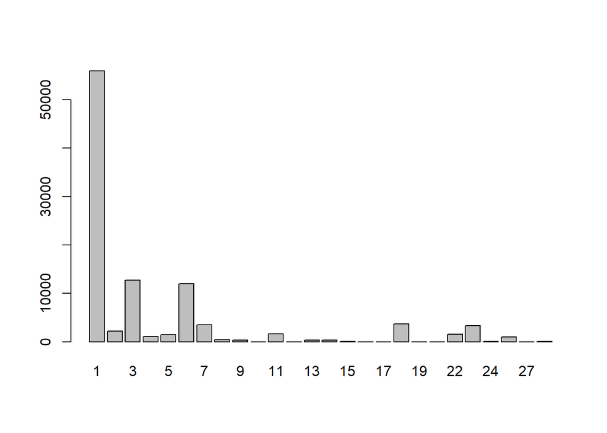

```r
barplot(table(data$discharge_disposition_id))
```

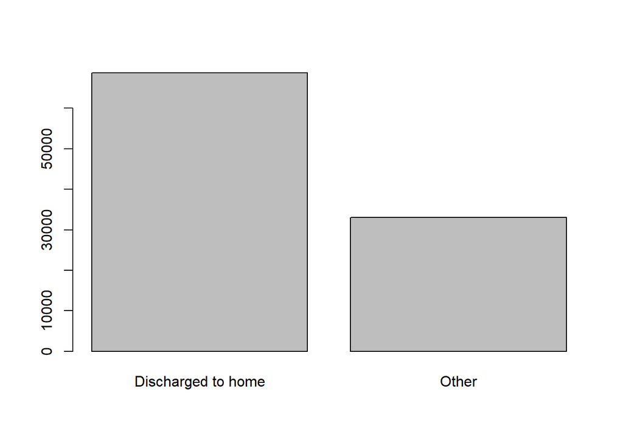

```r
data$discharge_disposition_id <- case_when(data$discharge_disposition_id %in% c("1","6","8","13","19") ~ "Discharged to home",
                                    data$discharge_disposition_id %in% c("2","3","4","5","7","9","10","11","12","14","15","17","20","21","22","23","24","27","28","29","30","18","25","26") ~   "Other")

data$discharge_disposition_id <- as.factor(data$discharge_disposition_id)


barplot(table(data$discharge_disposition_id))
```

Due to codes in csv file i change numeric values as “Referral”, “Other” and “Emergency”.

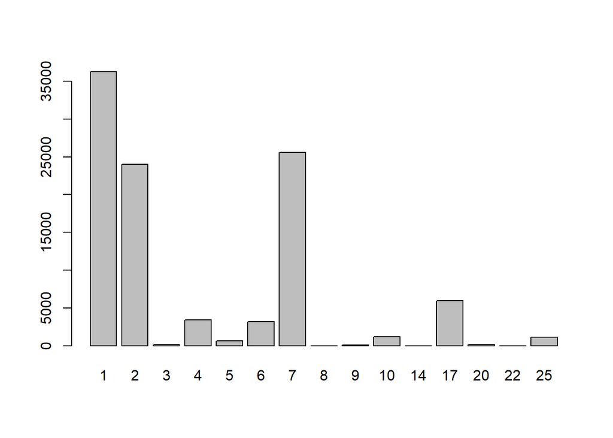

```r
barplot(table(data$admission_source_id))
```

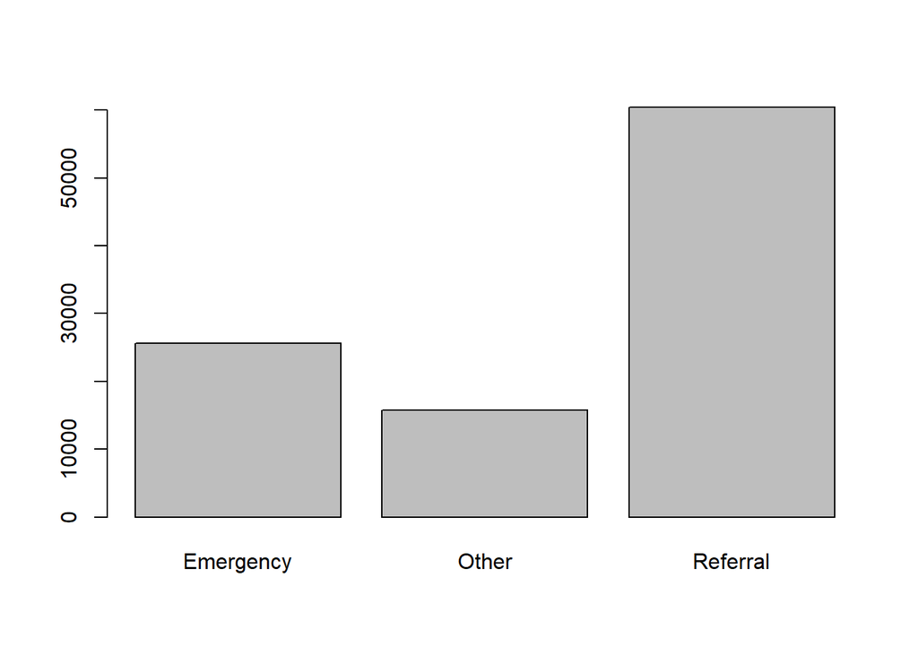

```r
data$admission_source_id <- case_when(data$admission_source_id %in% c("1","2","3") ~ "Referral",
                                    data$admission_source_id %in% c("4","5","6","8","9","10","11","12","13","14","15","17","18","19","20","21","22","23","24","25","26") ~   "Other",
                                    TRUE ~ "Emergency")

data$admission_source_id <- as.factor(data$admission_source_id)

barplot(table(data$admission_source_id))
```

Readmitted feature took 3 different values. No readmission(“No”), a readmission in more than 30 days(“>30”), a readmission in less than 30 days(“<30”). I assumed “> 30” and “NO” values as similar cases and converted it to binary class by encoding it as 0-1. Now, this feature tells us a patient readmitted in 30 days or not. Barplot shows this dataset is imbalanced. Imbalancing is a problem for classification.

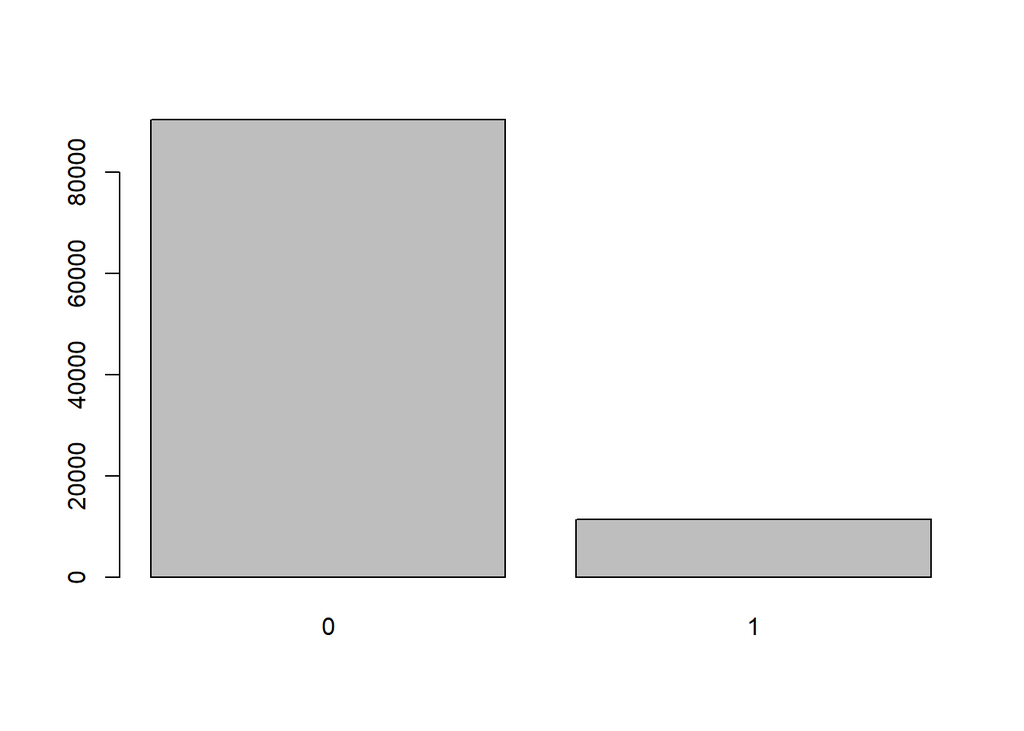

```r
data$readmitted <- case_when(data$readmitted %in% c(">30","NO") ~ "0",
                              TRUE ~ "1")
data$readmitted <- as.factor(data$readmitted)
barplot(table(data$readmitted))
```

Removed duplicated patients. After patient_nbr and encounter_id columns removed.

```r
data <- data[!duplicated(data$patient_nbr),]

data = select(data, -c(encounter_id, patient_nbr))

dim(data)
```

```
## [1] 71518    41
```

## Missing Data imputation

```r
calc_mode <- function(x){

  # List the distinct / unique values
  distinct_values <- unique(x)

  # Count the occurrence of each distinct value
  distinct_tabulate <- tabulate(match(x, distinct_values))

  # Return the value with the highest occurrence
  distinct_values[which.max(distinct_tabulate)]
}

imputeddata = data %>%
  mutate(gender = if_else(is.na(gender),
                         calc_mode(gender),
                         gender))

imputeddata = data %>%
  mutate(race = if_else(is.na(race),
                         calc_mode(race),
                         race))
dim(imputeddata)
```

```
## [1] 71518    41
```

diag_1 has missing values. So deleted rows with missing values.

```r
imputeddata = na.omit(imputeddata)
dim(imputeddata)
```

```
## [1] 71501    41
```

This barplot shows “diag_1” column. Diagnosis has ICD codes. I regroup them to categories in primary_diagnosis column.

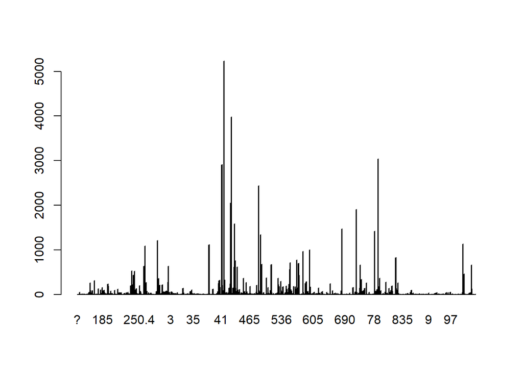

```r
barplot(table(imputeddata$diag_1))
```

I used the list of icd-9 codes for primary_diagnosis column.

```r
imputeddata$diag_1 <- as.character(imputeddata$diag_1)

imputeddata<- mutate(imputeddata, primary_diagnosis =
                                          ifelse(str_detect(diag_1, "V") | str_detect(diag_1, "E"),"Other",
                                          # disease codes starting with V or E are in “other” category;
                                          ifelse(str_detect(diag_1, "250"), "Diabetes",
                                          ifelse((as.integer(diag_1) >= 390 & as.integer(diag_1) <= 459) | as.integer(diag_1) == 785, "Circulatory",
                                          ifelse((as.integer(diag_1) >= 460 & as.integer(diag_1) <= 519) | as.integer(diag_1) == 786, "Respiratory",
                                          ifelse((as.integer(diag_1) >= 520 & as.integer(diag_1) <= 579) | as.integer(diag_1) == 787, "Digestive",
                                          ifelse((as.integer(diag_1) >= 580 & as.integer(diag_1) <= 629) | as.integer(diag_1) == 788, "Genitourinary",
                                          ifelse((as.integer(diag_1) >= 140 & as.integer(diag_1) <= 239), "Neoplasms",
                                          ifelse((as.integer(diag_1) >= 710 & as.integer(diag_1) <= 739), "Musculoskeletal",
                                          ifelse((as.integer(diag_1) >= 800 & as.integer(diag_1) <= 999), "Injury",
                                          "Other"))))))))))
table(imputeddata$primary_diagnosis)
```

```
##
##     Circulatory        Diabetes       Digestive   Genitourinary          Injury
##           21893            5805            6570            3514            4777
## Musculoskeletal       Neoplasms           Other     Respiratory
##            4080            2742           12344            9776
```

Removed “diag_1”. Make type of primary_diagnosis factor.

```r
imputeddata$primary_diagnosis <- as.factor(imputeddata$primary_diagnosis)
imputeddata$diag_1 <- NULL
```

## Splitting Data

Imputed data splitted into training and test sets with 80:20 proportion.

```r
set.seed(42)
train <- createDataPartition(imputeddata$readmitted, p = 0.8, list = FALSE)
training <- imputeddata[train, ]
testing <- imputeddata[-train, ]
table(training$readmitted)
```

```
##
##     0     1
## 52168  5033
```

## Balancing Dataset

I used “ROSE” (Random Over Sampling Examples) method for balancing dataset. ROSE method uses undersampling for class 0 (“>30” and “No”) and uses bootstrapping to increase artificial samples for class 1 (“<30”) to make the dataset balanced.

```r
data_rose = ROSE(readmitted ~., data = training)$data
table(data_rose$readmitted)
```

```
##
##     0     1
## 28826 28375
```

## Logistic Regression

I applied binary logistic regression to balanced and imputed data because “readmitted” column has binary values. Logistic Regression is the appropriate regression analysis to conduct when the dependent variable is binary.

```r
lreg<-train(readmitted~.,data=data_rose, method="glm",family="binomial")
```

Confusion matrix shows model has 84.31% accuracy.

```r
lreg_pred <- predict(lreg, testing)

confusionMatrix(lreg_pred, testing$readmitted)
```

```
## Confusion Matrix and Statistics
##
##           Reference
## Prediction     0     1
##          0 11016   218
##          1  2026  1040
##
##                Accuracy : 0.8431
##                  95% CI : (0.837, 0.849)
##     No Information Rate : 0.912
##     P-Value [Acc > NIR] : 1
##
##                   Kappa : 0.4071
##
##  Mcnemar's Test P-Value : <2e-16
##
##             Sensitivity : 0.8447
##             Specificity : 0.8267
##          Pos Pred Value : 0.9806
##          Neg Pred Value : 0.3392
##              Prevalence : 0.9120
##          Detection Rate : 0.7703
##    Detection Prevalence : 0.7856
##       Balanced Accuracy : 0.8357
##
##        'Positive' Class : 0
##
```

Variable Importances

```r
varImp(lreg)
```

```
## glm variable importance
##
##   only 20 most important variables shown (out of 82)
##
##                                  Overall
## discharge_disposition_idOther    100.000
## insulinUp                         57.146
## admission_source_idReferral       49.158
## admission_type_idEmergency        44.614
## num_procedures                    44.415
## insulinSteady                     39.430
## num_lab_procedures                39.274
## admission_source_idOther          34.433
## num_medications                   26.630
## number_inpatient                  21.846
## number_emergency                  21.739
## insulinNo                         18.449
## diabetesMedYes                    12.279
## primary_diagnosisMusculoskeletal  12.137
## primary_diagnosisRespiratory      10.079
## number_diagnoses                   7.533
## admission_type_idOther             7.281
## changeNo                           6.578
## raceAsian                          5.664
## max_glu_serumNone                  5.231
```

## Decision Tree

I applied decision tree classification to balanced and imputed data. Decision trees are one of the first to come to mind and most reliable algorithms for classification.

```r
dt<-train(readmitted~.,data=data_rose, method="rpart")
```

Confusion matrix shows accurary of model is 87.62%.

```r
dt_pred <- predict(dt, testing)

confusionMatrix(dt_pred, testing$readmitted)
```

```
## Confusion Matrix and Statistics
##
##           Reference
## Prediction     0     1
##          0 11651   379
##          1  1391   879
##
##                Accuracy : 0.8762
##                  95% CI : (0.8707, 0.8816)
##     No Information Rate : 0.912
##     P-Value [Acc > NIR] : 1
##
##                   Kappa : 0.4343
##
##  Mcnemar's Test P-Value : <2e-16
##
##             Sensitivity : 0.8933
##             Specificity : 0.6987
##          Pos Pred Value : 0.9685
##          Neg Pred Value : 0.3872
##              Prevalence : 0.9120
##          Detection Rate : 0.8148
##    Detection Prevalence : 0.8413
##       Balanced Accuracy : 0.7960
##
##        'Positive' Class : 0
##
```

## Decision Tree With Imbalanced Class

```r
imdt<-train(readmitted~.,data=training, method="rpart")
```

```r
imdt_pred <- predict(imdt, testing)

confusionMatrix(imdt_pred, testing$readmitted)
```

```
## Confusion Matrix and Statistics
##
##           Reference
## Prediction     0     1
##          0 12899   759
##          1   143   499
##
##                Accuracy : 0.9369
##                  95% CI : (0.9328, 0.9409)
##     No Information Rate : 0.912
##     P-Value [Acc > NIR] : < 2.2e-16
##
##                   Kappa : 0.4953
##
##  Mcnemar's Test P-Value : < 2.2e-16
##
##             Sensitivity : 0.9890
##             Specificity : 0.3967
##          Pos Pred Value : 0.9444
##          Neg Pred Value : 0.7773
##              Prevalence : 0.9120
##          Detection Rate : 0.9020
##    Detection Prevalence : 0.9551
##       Balanced Accuracy : 0.6928
##
##        'Positive' Class : 0
##
```

If I compare statistics of the balanced and imbalanced models accuracy of imbalanced model is better. But accuracy score is not a good metric for imbalanced classification. With imbalanced model, specificity is too low and sensitivity is too high that is not good.

## Kmeans Clustering

```r
kmodel <- kmeans(imputeddata[c("time_in_hospital", "num_lab_procedures", "num_procedures", "number_outpatient", "number_emergency", "num_medications", "number_inpatient", "number_diagnoses")], centers = 2)
km_cluster <- data.frame(imputeddata[c("time_in_hospital", "num_lab_procedures", "num_procedures", "number_outpatient", "number_emergency", "num_medications", "number_inpatient", "number_diagnoses")],
  cluster = as.factor(kmodel$cluster)
)

head(km_cluster)
```

```
##   time_in_hospital num_lab_procedures num_procedures number_outpatient
## 1                1                 41              0                 0
## 2                3                 59              0                 0
## 3                2                 11              5                 2
## 4                2                 44              1                 0
## 5                1                 51              0                 0
## 6                3                 31              6                 0
##   number_emergency num_medications number_inpatient number_diagnoses cluster
## 1                0               1                0                1       2
## 2                0              18                0                9       2
## 3                0              13                1                6       1
## 4                0              16                0                7       2
## 5                0               8                0                5       2
## 6                0              16                0                9       1
```

```r
(BSS <- kmodel$betweenss)
```

```
## [1] 24456746
```

```r
(TSS <- kmodel$totss)
```

```
## [1] 41722276
```

```r
BSS / TSS * 100
```

```
## [1] 58.61796
```

```r
kmodel3 <- kmeans(imputeddata[c("time_in_hospital", "num_lab_procedures", "num_procedures", "number_outpatient", "number_emergency", "num_medications", "number_inpatient", "number_diagnoses")], centers = 3)
km_cluster3 <- data.frame(imputeddata[c("time_in_hospital", "num_lab_procedures", "num_procedures", "number_outpatient", "number_emergency", "num_medications", "number_inpatient", "number_diagnoses")],
  cluster = as.factor(kmodel3$cluster)
)

head(km_cluster3)
```

```
##   time_in_hospital num_lab_procedures num_procedures number_outpatient
## 1                1                 41              0                 0
## 2                3                 59              0                 0
## 3                2                 11              5                 2
## 4                2                 44              1                 0
## 5                1                 51              0                 0
## 6                3                 31              6                 0
##   number_emergency num_medications number_inpatient number_diagnoses cluster
## 1                0               1                0                1       2
## 2                0              18                0                9       1
## 3                0              13                1                6       3
## 4                0              16                0                7       2
## 5                0               8                0                5       2
## 6                0              16                0                9       2
```

```r
(BSS <- kmodel3$betweenss)
```

```
## [1] 29515397
```

```r
(TSS <- kmodel3$totss)
```

```
## [1] 41722276
```

```r
BSS / TSS * 100
```

```
## [1] 70.74254
```

```r
kmodel4 <- kmeans(imputeddata[c("time_in_hospital", "num_lab_procedures", "num_procedures", "number_outpatient", "number_emergency", "num_medications", "number_inpatient", "number_diagnoses")], centers = 4)
km_cluster4 <- data.frame(imputeddata[c("time_in_hospital", "num_lab_procedures", "num_procedures", "number_outpatient", "number_emergency", "num_medications", "number_inpatient", "number_diagnoses")],
  cluster = as.factor(kmodel4$cluster)
)

head(km_cluster4)
```

```
##   time_in_hospital num_lab_procedures num_procedures number_outpatient
## 1                1                 41              0                 0
## 2                3                 59              0                 0
## 3                2                 11              5                 2
## 4                2                 44              1                 0
## 5                1                 51              0                 0
## 6                3                 31              6                 0
##   number_emergency num_medications number_inpatient number_diagnoses cluster
## 1                0               1                0                1       4
## 2                0              18                0                9       4
## 3                0              13                1                6       1
## 4                0              16                0                7       4
## 5                0               8                0                5       4
## 6                0              16                0                9       2
```

```r
(BSS <- kmodel4$betweenss)
```

```
## [1] 31804480
```

```r
(TSS <- kmodel4$totss)
```

```
## [1] 41722276
```

```r
BSS / TSS * 100
```

```
## [1] 76.22902
```

I calculated the quality of the partition for 2 center, 3 center, 4 center respectively.

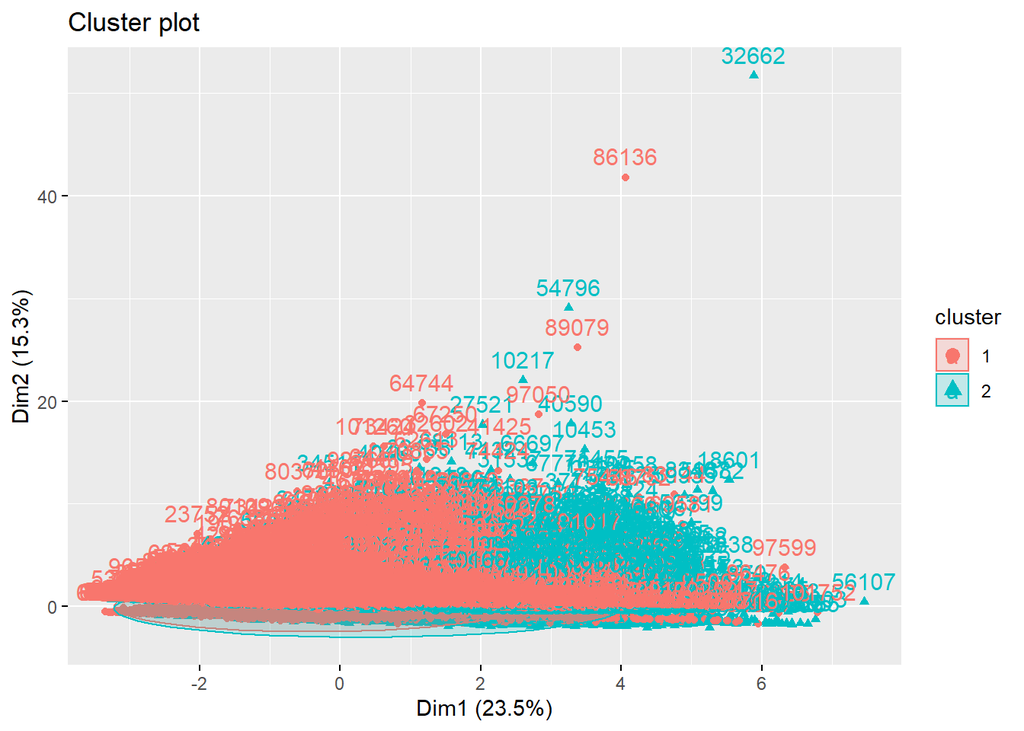

```r
fviz_cluster(kmodel, imputeddata[c("time_in_hospital", "num_lab_procedures", "num_procedures", "number_outpatient", "number_emergency", "num_medications", "number_inpatient", "number_diagnoses")], ellipse.type = "norm")
```

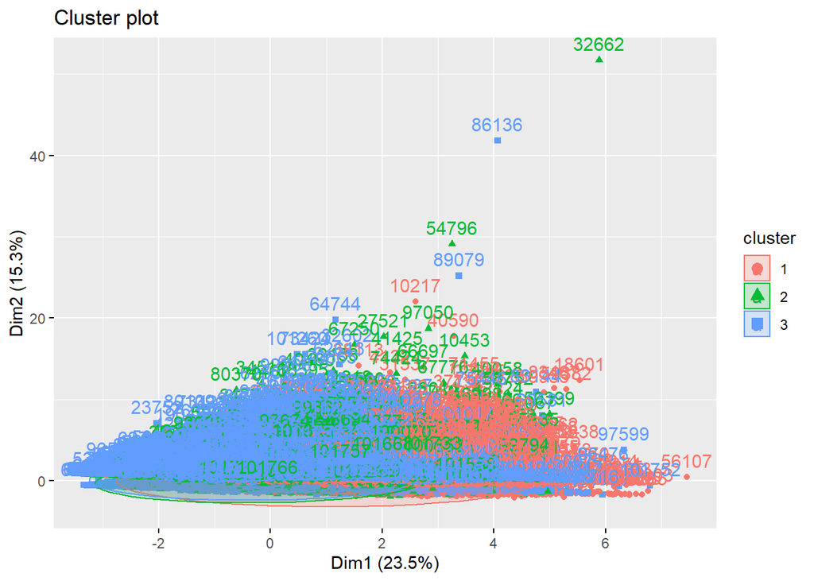

```r
fviz_cluster(kmodel3, imputeddata[c("time_in_hospital", "num_lab_procedures", "num_procedures", "number_outpatient", "number_emergency", "num_medications", "number_inpatient", "number_diagnoses")], ellipse.type = "norm")
```

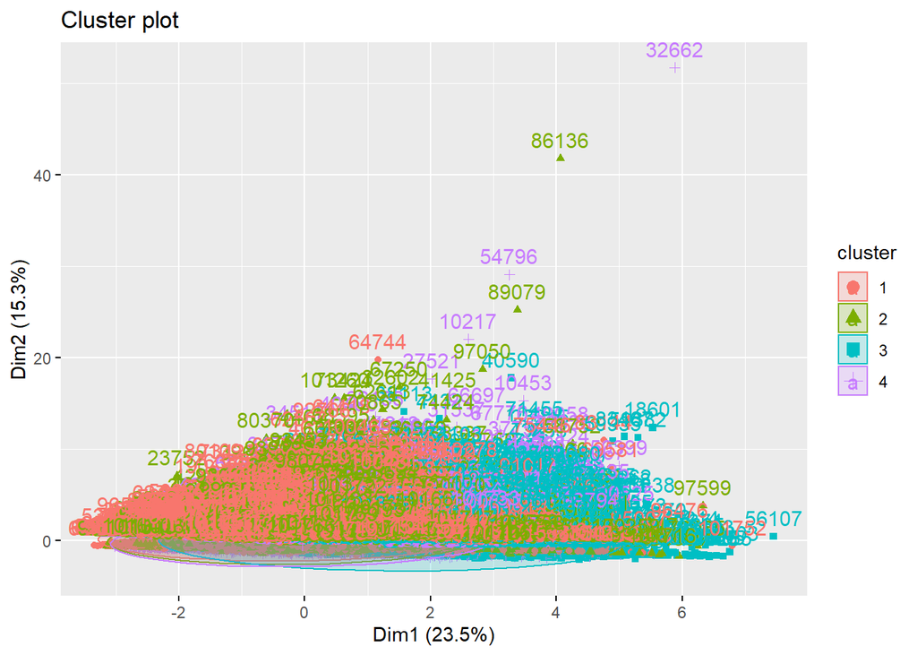

```r
fviz_cluster(kmodel4, imputeddata[c("time_in_hospital", "num_lab_procedures", "num_procedures", "number_outpatient", "number_emergency", "num_medications", "number_inpatient", "number_diagnoses")], ellipse.type = "norm")
```

I plot clusters by using the fviz_cluster() function for 2 center, 3 center, 4 center respectively. With this plots and quality scores I can say 2 or 3 clusteri is enough.